# *End to End Machine Learning Project*

1. Download the data.
2. Load the data
3. Visualize each attribute from loaded data.
4. Create a test data using StratifiedShuffleSplit.
5. Calculate standard correlation coefficient to know the required attributes.(0,1,-1) => 0 independent, 1,-1=> dependent.
6. Remove predicted attribute to prepare the data for ML algorithms.
7. Data cleaning=> 7.1 Numerical values clean, => SimpleImputer 7.2 convert Text attributes to categorical values(numerical). => OneHotEncoder
8. Feature Scaling => Transform all the attribute values into same scale. => StandardScaler.
9. Transformation Pipelines => combines numerical, categorical attributes. => ColumnTransformer.
10. Select the Models, check the error rate and check whether overfitting or underfitting and select the models. (2 to 5).
11. Fine tune the model
12. Evaluate the System on the Test Set
13. Launch, Monitor, and Maintain the System

# 1. Download the data

Downloading the data from available source and writing script to extract the data from tgz to csv It is useful when the data is changed regularly, then it is better to write a script and whenever the data changes then I can run the script so that the data will extract and can fetch latest data. To do this automatically can be done through Job scheduling. It also helps if needed to run in multiple machines.

```python
import os
import tarfile
from six.moves import urllib
```

```python
 DOWNLOAD_ROOT = "https://raw.githubusercontent.com/ageron/handson-ml2/master/"
 HOUSING_PATH = os.path.join("datasets", "housing")
 HOUSING_URL = DOWNLOAD_ROOT + "datasets/housing/housing.tgz"
```

```python
def fetch_housing_data(housing_url=HOUSING_URL,housing_path=HOUSING_PATH):
    if not os.path.isdir(housing_path):
        os.makedirs(housing_path)
    tgz_path = os.path.join(housing_path,"housing.tgz")
    urllib.request.urlretrieve(housing_url,tgz_path)
    housing_tgz = tarfile.open(tgz_path)
    housing_tgz.extractall(path=housing_path)
    housing_tgz.close()

fetch_housing_data()
```

The data is stored in This PC>C:>Users>venis>datasets>housing>housing.csv

# 2. Load the data

Now lets load the data using pandas

```python
import pandas as pd
```

```python
def load_housing_data(housing_path=HOUSING_PATH):
    csv_path = os.path.join(housing_path,"housing.csv")
    return pd.read_csv(csv_path)
```

```python
df_housing = load_housing_data()
df_housing
```

|  | longitude | latitude | housing_median_age | total_rooms | total_bedrooms | population | households | median_income | median_house_value | ocean_proximity |
| --- | --- | --- | --- | --- | --- | --- | --- | --- | --- | --- |
| 0 | -122.23 | 37.88 | 41.0 | 880.0 | 129.0 | 322.0 | 126.0 | 8.3252 | 452600.0 | NEAR BAY |
| 1 | -122.22 | 37.86 | 21.0 | 7099.0 | 1106.0 | 2401.0 | 1138.0 | 8.3014 | 358500.0 | NEAR BAY |
| 2 | -122.24 | 37.85 | 52.0 | 1467.0 | 190.0 | 496.0 | 177.0 | 7.2574 | 352100.0 | NEAR BAY |
| 3 | -122.25 | 37.85 | 52.0 | 1274.0 | 235.0 | 558.0 | 219.0 | 5.6431 | 341300.0 | NEAR BAY |
| 4 | -122.25 | 37.85 | 52.0 | 1627.0 | 280.0 | 565.0 | 259.0 | 3.8462 | 342200.0 | NEAR BAY |
| ... | ... | ... | ... | ... | ... | ... | ... | ... | ... | ... |
| 20635 | -121.09 | 39.48 | 25.0 | 1665.0 | 374.0 | 845.0 | 330.0 | 1.5603 | 78100.0 | INLAND |
| 20636 | -121.21 | 39.49 | 18.0 | 697.0 | 150.0 | 356.0 | 114.0 | 2.5568 | 77100.0 | INLAND |
| 20637 | -121.22 | 39.43 | 17.0 | 2254.0 | 485.0 | 1007.0 | 433.0 | 1.7000 | 92300.0 | INLAND |
| 20638 | -121.32 | 39.43 | 18.0 | 1860.0 | 409.0 | 741.0 | 349.0 | 1.8672 | 84700.0 | INLAND |
| 20639 | -121.24 | 39.37 | 16.0 | 2785.0 | 616.0 | 1387.0 | 530.0 | 2.3886 | 89400.0 | INLAND |

20640 rows × 10 columns

```python
df_housing.count()
```

```
longitude             20640
latitude              20640
housing_median_age    20640
total_rooms           20640
total_bedrooms        20433
population            20640
households            20640
median_income         20640
median_house_value    20640
ocean_proximity       20640
dtype: int64
```

```python
df_housing.head() #to get top 5 rows from data frame
```

|  | longitude | latitude | housing_median_age | total_rooms | total_bedrooms | population | households | median_income | median_house_value | ocean_proximity |
| --- | --- | --- | --- | --- | --- | --- | --- | --- | --- | --- |
| 0 | -122.23 | 37.88 | 41.0 | 880.0 | 129.0 | 322.0 | 126.0 | 8.3252 | 452600.0 | NEAR BAY |
| 1 | -122.22 | 37.86 | 21.0 | 7099.0 | 1106.0 | 2401.0 | 1138.0 | 8.3014 | 358500.0 | NEAR BAY |
| 2 | -122.24 | 37.85 | 52.0 | 1467.0 | 190.0 | 496.0 | 177.0 | 7.2574 | 352100.0 | NEAR BAY |
| 3 | -122.25 | 37.85 | 52.0 | 1274.0 | 235.0 | 558.0 | 219.0 | 5.6431 | 341300.0 | NEAR BAY |
| 4 | -122.25 | 37.85 | 52.0 | 1627.0 | 280.0 | 565.0 | 259.0 | 3.8462 | 342200.0 | NEAR BAY |

```python
df_housing.info()
```

```
<class 'pandas.core.frame.DataFrame'>
RangeIndex: 20640 entries, 0 to 20639
Data columns (total 10 columns):
 #   Column              Non-Null Count  Dtype
---  ------              --------------  -----
 0   longitude           20640 non-null  float64
 1   latitude            20640 non-null  float64
 2   housing_median_age  20640 non-null  float64
 3   total_rooms         20640 non-null  float64
 4   total_bedrooms      20433 non-null  float64
 5   population          20640 non-null  float64
 6   households          20640 non-null  float64
 7   median_income       20640 non-null  float64
 8   median_house_value  20640 non-null  float64
 9   ocean_proximity     20640 non-null  object
dtypes: float64(9), object(1)
memory usage: 1.6+ MB
```

The districts are categorized into values Ocean_proximity Now to know the catgories and the district counts of each category.

```python
df_housing["ocean_proximity"].value_counts()
```

```
<1H OCEAN     9136
INLAND        6551
NEAR OCEAN    2658
NEAR BAY      2290
ISLAND           5
Name: ocean_proximity, dtype: int64
```

To get the statistics for each field in the dataframe. This describe method calculates only for numerical values.

```python
df_housing.describe()
```

|  | longitude | latitude | housing_median_age | total_rooms | total_bedrooms | population | households | median_income | median_house_value |
| --- | --- | --- | --- | --- | --- | --- | --- | --- | --- |
| count | 20640.000000 | 20640.000000 | 20640.000000 | 20640.000000 | 20433.000000 | 20640.000000 | 20640.000000 | 20640.000000 | 20640.000000 |
| mean | -119.569704 | 35.631861 | 28.639486 | 2635.763081 | 537.870553 | 1425.476744 | 499.539680 | 3.870671 | 206855.816909 |
| std | 2.003532 | 2.135952 | 12.585558 | 2181.615252 | 421.385070 | 1132.462122 | 382.329753 | 1.899822 | 115395.615874 |
| min | -124.350000 | 32.540000 | 1.000000 | 2.000000 | 1.000000 | 3.000000 | 1.000000 | 0.499900 | 14999.000000 |
| 25% | -121.800000 | 33.930000 | 18.000000 | 1447.750000 | 296.000000 | 787.000000 | 280.000000 | 2.563400 | 119600.000000 |
| 50% | -118.490000 | 34.260000 | 29.000000 | 2127.000000 | 435.000000 | 1166.000000 | 409.000000 | 3.534800 | 179700.000000 |
| 75% | -118.010000 | 37.710000 | 37.000000 | 3148.000000 | 647.000000 | 1725.000000 | 605.000000 | 4.743250 | 264725.000000 |
| max | -114.310000 | 41.950000 | 52.000000 | 39320.000000 | 6445.000000 | 35682.000000 | 6082.000000 | 15.000100 | 500001.000000 |

# 3. Visualize each attribute from loaded data

A histogram for each numerical attribute

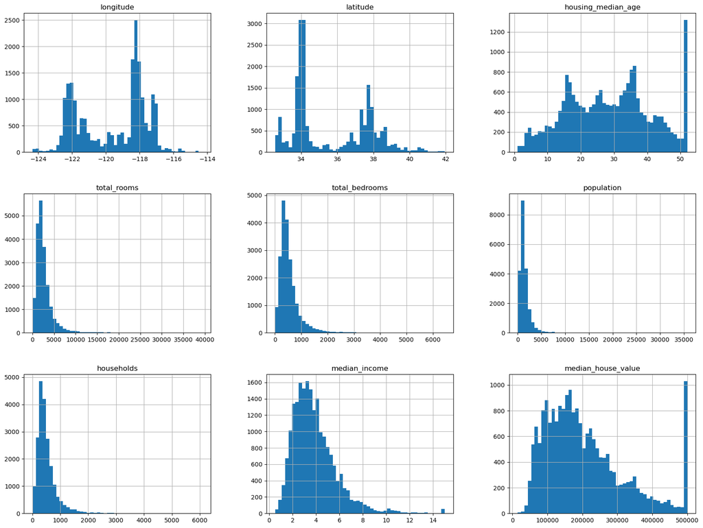

```python
%matplotlib inline
import matplotlib.pyplot as plt
df_housing.hist(bins=50, figsize=(20,15))
plt.show()
```

# 4. Create Test data

First we have to set some ratio of data aside for testing. steps to create test data:

1. Shuffle the indices of the data randomly by applying permutation.
2. To get length/size of the test data, multiply the length of the data to ratio of the test data.
3. assign the length for train set and test set
4. return the index locations of test and train data set.

Data Snooping bias: while keeping aside, our human brains do think to train the data according to test data and get intersting pattern based on that and that leads to selecting Machine learning model. And while estimating generalization error set, the estimate will be almost equal on the test set, train set and when we deploy it into production the error rate(generalization error) varies than expected. This kind of thinking to train the data according to test data is is called Data Snooping bias.

```python
import numpy as np
def split_train_test(data, test_ratio):
    shuffle_indices = np.random.permutation(len(data))
    test_set_size = int(len(data)* test_ratio)
    test_indices = shuffle_indices[:test_set_size]
    train_indices = shuffle_indices[test_set_size:]
    return data.iloc[train_indices], data.iloc[test_indices]
```

```python
train_set, test_set = split_train_test(df_housing, 0.2)
len(test_set)
```

```
4128
```

```python
len(train_set)
```

```
16512
```

```python
from zlib import crc32
```

```python
def test_set_check(identifier, test_ratio):
    return crc32(np.int64(identifier)) & 0xffffffff < test_ratio * 2**32
```

```python
def split_train_test_by_id(data, test_ratio, id_column):
    ids = data[id_column]
    in_test_set = ids.apply(lambda id_: test_set_check(id_, test_ratio))
    return data.loc[~in_test_set], data.loc[in_test_set]
```

Unfortunetly housing data doesnot have identifier column, so using Row index as ID it adds new column as index, else use ID = (longitude*1000 + latitude)

```python
housing_with_id = df_housing.reset_index()
# train_set, test_set = split_train_test_by_id(housing_with_id, 0.2, "index")
housing_with_id["id"] = df_housing["longitude"] * 1000 + df_housing["latitude"]
train_set, test_set = split_train_test_by_id(housing_with_id, 0.2, "id")
```

```python
len(test_set)
```

```
4318
```

Same as split_train_test process but using scikit-learn model

```python
 from sklearn.model_selection import train_test_split
 train_set, test_set = train_test_split(df_housing, test_size=0.2, random_state=42)
```

```python
len(test_set)
```

```
4128
```

# 5. Stratify sampling based on the income category

This step is about categorizing median income for reducing sampling bais in test data.

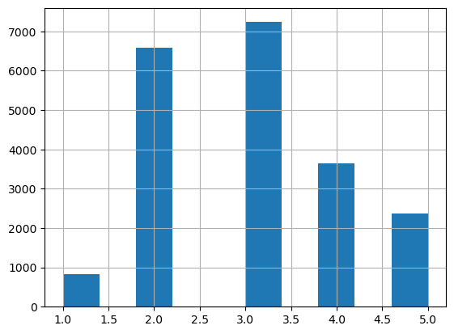

```python
df_housing["income_category"] = pd.cut(df_housing["median_income"], bins=[0.,1.5,3.0,4.5,6., np.inf],
                                      labels = [1,2,3,4,5])
df_housing["income_category"].hist()
```

In this step, Take 20% from each category as test data then the data is stratified sampling based on the income category. No sampling bais in test data. For this use Scikit-Learn’s StratifiedShuffleSplit class.

```python
from sklearn.model_selection import StratifiedShuffleSplit
split = StratifiedShuffleSplit(n_splits=1,test_size=0.2,random_state=42)
for train_index, test_index in split.split(df_housing, df_housing["income_category"]):
    strat_train_set = df_housing.loc[train_index]
    strat_test_set = df_housing.loc[test_index]
```

```python
len(strat_test_set)
```

```
4128
```

```python
df_housing["income_category"].value_counts()
```

```
3    7236
2    6581
4    3639
5    2362
1     822
Name: income_category, dtype: int64
```

20% of each category from whole dataset of income_category

```python
strat_test_set["income_category"].value_counts()
```

```
3    1447
2    1316
4     728
5     472
1     165
Name: income_category, dtype: int64
```

percentage of each category from median income in test set

```python
strat_test_set["income_category"].value_counts()/len(strat_test_set)
```

```
3    0.350533
2    0.318798
4    0.176357
5    0.114341
1    0.039971
Name: income_category, dtype: float64
```

```python
df_housing
```

|  | longitude | latitude | housing_median_age | total_rooms | total_bedrooms | population | households | median_income | median_house_value | ocean_proximity | income_category |
| --- | --- | --- | --- | --- | --- | --- | --- | --- | --- | --- | --- |
| 0 | -122.23 | 37.88 | 41.0 | 880.0 | 129.0 | 322.0 | 126.0 | 8.3252 | 452600.0 | NEAR BAY | 5 |
| 1 | -122.22 | 37.86 | 21.0 | 7099.0 | 1106.0 | 2401.0 | 1138.0 | 8.3014 | 358500.0 | NEAR BAY | 5 |
| 2 | -122.24 | 37.85 | 52.0 | 1467.0 | 190.0 | 496.0 | 177.0 | 7.2574 | 352100.0 | NEAR BAY | 5 |
| 3 | -122.25 | 37.85 | 52.0 | 1274.0 | 235.0 | 558.0 | 219.0 | 5.6431 | 341300.0 | NEAR BAY | 4 |
| 4 | -122.25 | 37.85 | 52.0 | 1627.0 | 280.0 | 565.0 | 259.0 | 3.8462 | 342200.0 | NEAR BAY | 3 |
| ... | ... | ... | ... | ... | ... | ... | ... | ... | ... | ... | ... |
| 20635 | -121.09 | 39.48 | 25.0 | 1665.0 | 374.0 | 845.0 | 330.0 | 1.5603 | 78100.0 | INLAND | 2 |
| 20636 | -121.21 | 39.49 | 18.0 | 697.0 | 150.0 | 356.0 | 114.0 | 2.5568 | 77100.0 | INLAND | 2 |
| 20637 | -121.22 | 39.43 | 17.0 | 2254.0 | 485.0 | 1007.0 | 433.0 | 1.7000 | 92300.0 | INLAND | 2 |
| 20638 | -121.32 | 39.43 | 18.0 | 1860.0 | 409.0 | 741.0 | 349.0 | 1.8672 | 84700.0 | INLAND | 2 |
| 20639 | -121.24 | 39.37 | 16.0 | 2785.0 | 616.0 | 1387.0 | 530.0 | 2.3886 | 89400.0 | INLAND | 2 |

20640 rows × 11 columns

To drop income_category

```python
# for set_ in (strat_train_set, strat_test_set):
#     set_.drop("income_category", axis=1, inplace=True)
```

# TEST SET

```python
strat_test_set
```

|  | longitude | latitude | housing_median_age | total_rooms | total_bedrooms | population | households | median_income | median_house_value | ocean_proximity | income_category |
| --- | --- | --- | --- | --- | --- | --- | --- | --- | --- | --- | --- |
| 5241 | -118.39 | 34.12 | 29.0 | 6447.0 | 1012.0 | 2184.0 | 960.0 | 8.2816 | 500001.0 | <1H OCEAN | 5 |
| 17352 | -120.42 | 34.89 | 24.0 | 2020.0 | 307.0 | 855.0 | 283.0 | 5.0099 | 162500.0 | <1H OCEAN | 4 |
| 3505 | -118.45 | 34.25 | 36.0 | 1453.0 | 270.0 | 808.0 | 275.0 | 4.3839 | 204600.0 | <1H OCEAN | 3 |
| 7777 | -118.10 | 33.91 | 35.0 | 1653.0 | 325.0 | 1072.0 | 301.0 | 3.2708 | 159700.0 | <1H OCEAN | 3 |
| 14155 | -117.07 | 32.77 | 38.0 | 3779.0 | 614.0 | 1495.0 | 614.0 | 4.3529 | 184000.0 | NEAR OCEAN | 3 |
| ... | ... | ... | ... | ... | ... | ... | ... | ... | ... | ... | ... |
| 12182 | -117.29 | 33.72 | 19.0 | 2248.0 | 427.0 | 1207.0 | 368.0 | 2.8170 | 110000.0 | <1H OCEAN | 2 |
| 7275 | -118.24 | 33.99 | 33.0 | 885.0 | 294.0 | 1270.0 | 282.0 | 2.1615 | 118800.0 | <1H OCEAN | 2 |
| 17223 | -119.72 | 34.44 | 43.0 | 1781.0 | 342.0 | 663.0 | 358.0 | 4.7000 | 293800.0 | <1H OCEAN | 4 |
| 10786 | -117.91 | 33.63 | 30.0 | 2071.0 | 412.0 | 1081.0 | 412.0 | 4.9125 | 335700.0 | <1H OCEAN | 4 |
| 3965 | -118.56 | 34.19 | 36.0 | 2600.0 | 441.0 | 1246.0 | 426.0 | 4.1111 | 215600.0 | <1H OCEAN | 3 |

4128 rows × 11 columns

# WHOLE SET

```python
df_housing
```

|  | longitude | latitude | housing_median_age | total_rooms | total_bedrooms | population | households | median_income | median_house_value | ocean_proximity | income_category |
| --- | --- | --- | --- | --- | --- | --- | --- | --- | --- | --- | --- |
| 0 | -122.23 | 37.88 | 41.0 | 880.0 | 129.0 | 322.0 | 126.0 | 8.3252 | 452600.0 | NEAR BAY | 5 |
| 1 | -122.22 | 37.86 | 21.0 | 7099.0 | 1106.0 | 2401.0 | 1138.0 | 8.3014 | 358500.0 | NEAR BAY | 5 |
| 2 | -122.24 | 37.85 | 52.0 | 1467.0 | 190.0 | 496.0 | 177.0 | 7.2574 | 352100.0 | NEAR BAY | 5 |
| 3 | -122.25 | 37.85 | 52.0 | 1274.0 | 235.0 | 558.0 | 219.0 | 5.6431 | 341300.0 | NEAR BAY | 4 |
| 4 | -122.25 | 37.85 | 52.0 | 1627.0 | 280.0 | 565.0 | 259.0 | 3.8462 | 342200.0 | NEAR BAY | 3 |
| ... | ... | ... | ... | ... | ... | ... | ... | ... | ... | ... | ... |
| 20635 | -121.09 | 39.48 | 25.0 | 1665.0 | 374.0 | 845.0 | 330.0 | 1.5603 | 78100.0 | INLAND | 2 |
| 20636 | -121.21 | 39.49 | 18.0 | 697.0 | 150.0 | 356.0 | 114.0 | 2.5568 | 77100.0 | INLAND | 2 |
| 20637 | -121.22 | 39.43 | 17.0 | 2254.0 | 485.0 | 1007.0 | 433.0 | 1.7000 | 92300.0 | INLAND | 2 |
| 20638 | -121.32 | 39.43 | 18.0 | 1860.0 | 409.0 | 741.0 | 349.0 | 1.8672 | 84700.0 | INLAND | 2 |
| 20639 | -121.24 | 39.37 | 16.0 | 2785.0 | 616.0 | 1387.0 | 530.0 | 2.3886 | 89400.0 | INLAND | 2 |

20640 rows × 11 columns

# TRAIN SET

```python
housing_train_set = strat_train_set.copy()
housing_train_set
```

|  | longitude | latitude | housing_median_age | total_rooms | total_bedrooms | population | households | median_income | median_house_value | ocean_proximity | income_category |
| --- | --- | --- | --- | --- | --- | --- | --- | --- | --- | --- | --- |
| 12655 | -121.46 | 38.52 | 29.0 | 3873.0 | 797.0 | 2237.0 | 706.0 | 2.1736 | 72100.0 | INLAND | 2 |
| 15502 | -117.23 | 33.09 | 7.0 | 5320.0 | 855.0 | 2015.0 | 768.0 | 6.3373 | 279600.0 | NEAR OCEAN | 5 |
| 2908 | -119.04 | 35.37 | 44.0 | 1618.0 | 310.0 | 667.0 | 300.0 | 2.8750 | 82700.0 | INLAND | 2 |
| 14053 | -117.13 | 32.75 | 24.0 | 1877.0 | 519.0 | 898.0 | 483.0 | 2.2264 | 112500.0 | NEAR OCEAN | 2 |
| 20496 | -118.70 | 34.28 | 27.0 | 3536.0 | 646.0 | 1837.0 | 580.0 | 4.4964 | 238300.0 | <1H OCEAN | 3 |
| ... | ... | ... | ... | ... | ... | ... | ... | ... | ... | ... | ... |
| 15174 | -117.07 | 33.03 | 14.0 | 6665.0 | 1231.0 | 2026.0 | 1001.0 | 5.0900 | 268500.0 | <1H OCEAN | 4 |
| 12661 | -121.42 | 38.51 | 15.0 | 7901.0 | 1422.0 | 4769.0 | 1418.0 | 2.8139 | 90400.0 | INLAND | 2 |
| 19263 | -122.72 | 38.44 | 48.0 | 707.0 | 166.0 | 458.0 | 172.0 | 3.1797 | 140400.0 | <1H OCEAN | 3 |
| 19140 | -122.70 | 38.31 | 14.0 | 3155.0 | 580.0 | 1208.0 | 501.0 | 4.1964 | 258100.0 | <1H OCEAN | 3 |
| 19773 | -122.14 | 39.97 | 27.0 | 1079.0 | 222.0 | 625.0 | 197.0 | 3.1319 | 62700.0 | INLAND | 3 |

16512 rows × 11 columns

# 6. A geographical scatterplot of the data(train set)

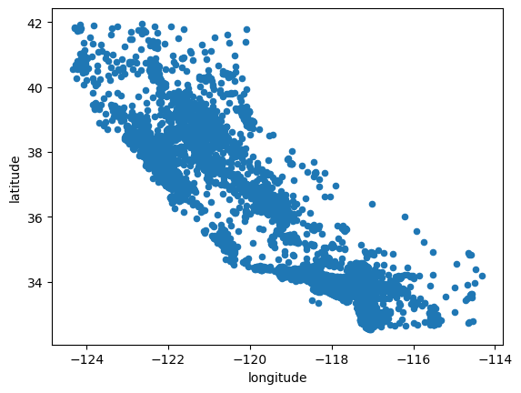

```python
housing_train_set.plot(kind="scatter",x="longitude",y="latitude")
```

Dense areas look darker, sparse areas look lighter

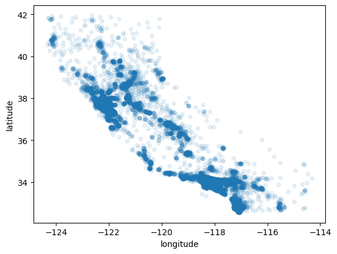

```python
housing_train_set.plot(kind="scatter",x="longitude",y="latitude",alpha=0.1)
```

s = The radius of each circle which represents the district’s population.

c = The color represents the price.

jet in cmap = Predefined color map.

color ranges = blue to red.

blue = low median housing prices.

red = high median housing prices.

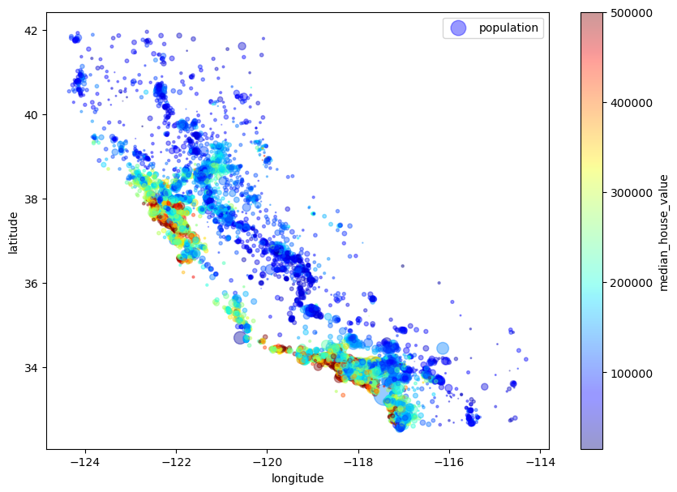

```python
housing_train_set.plot(kind="scatter",x="longitude",y="latitude",alpha=0.4,s=housing_train_set["population"]/100,
                      label= "population", figsize=(10,7), c="median_house_value", cmap=plt.get_cmap("jet"),colorbar=True)
plt.legend()
```

# 7. standard correlation coefficient (also called Pearson’s r)

correlation = How strongly are two attributes related to each other.

coefficient = A coefficient is just a number that multiplies something.

correlation coefficient = Number that tells you how strong and in what direction two attributes (variables) are related.

standard correlation coefficient(Pearson’s correlation coefficient) = The value of Pearson’s r ranges between:

+1 = perfect positive linear relationship

(e.g., as one goes up, the other always goes up)

0 = no linear relationship

(e.g., the two are totally unrelated)

−1 = perfect negative linear relationship

(e.g., as one goes up, the other always goes down)

Formula => r = cov(X, Y) / (std(X) * std(Y))

cov(X, Y) = (sum(x - mean(x))sum(y-mean(y)))/sqrt(sum(x - mean(x))^2 * sum(y - mean(y))^2)

x - Each individual value of variable X

𝑦 - Each individual value of variable Y

mean(x) - Mean (average) of all X values

mean(𝑦) - Mean (average) of all Y values

Summation (add up all values)

```python
corr_matrix = housing_train_set.corr()
```

```python
corr_matrix["median_house_value"].sort_values(ascending=False)
```

```
median_house_value    1.000000
median_income         0.687151
total_rooms           0.135140
housing_median_age    0.114146
households            0.064590
total_bedrooms        0.047781
population           -0.026882
longitude            -0.047466
latitude             -0.142673
Name: median_house_value, dtype: float64
```

# 8. Scatter matrix of standard correlation coefficient

if standard correlation coefficient is 1 => linear correlation goes up for up, down for down.

if standard correlation coefficient is -1 => linear correlation goes up for down, down for up.

if standard correlation coefficient is 0 => Nonlinear correlation(attributes not depending on each other).

scatter_matrix function => which plots every numerical attribute against every other numerical attribute. Since there are now 11 numerical attributes, would get 11^2 = 121 plots, we will plot for only related attributes.

```
array([[<AxesSubplot:xlabel='median_house_value', ylabel='median_house_value'>,
        <AxesSubplot:xlabel='median_income', ylabel='median_house_value'>,
        <AxesSubplot:xlabel='total_rooms', ylabel='median_house_value'>,
        <AxesSubplot:xlabel='housing_median_age', ylabel='median_house_value'>],
       [<AxesSubplot:xlabel='median_house_value', ylabel='median_income'>,
        <AxesSubplot:xlabel='median_income', ylabel='median_income'>,
        <AxesSubplot:xlabel='total_rooms', ylabel='median_income'>,
        <AxesSubplot:xlabel='housing_median_age', ylabel='median_income'>],
       [<AxesSubplot:xlabel='median_house_value', ylabel='total_rooms'>,
        <AxesSubplot:xlabel='median_income', ylabel='total_rooms'>,
        <AxesSubplot:xlabel='total_rooms', ylabel='total_rooms'>,
        <AxesSubplot:xlabel='housing_median_age', ylabel='total_rooms'>],
       [<AxesSubplot:xlabel='median_house_value', ylabel='housing_median_age'>,
        <AxesSubplot:xlabel='median_income', ylabel='housing_median_age'>,
        <AxesSubplot:xlabel='total_rooms', ylabel='housing_median_age'>,
        <AxesSubplot:xlabel='housing_median_age', ylabel='housing_median_age'>]],
      dtype=object)
```

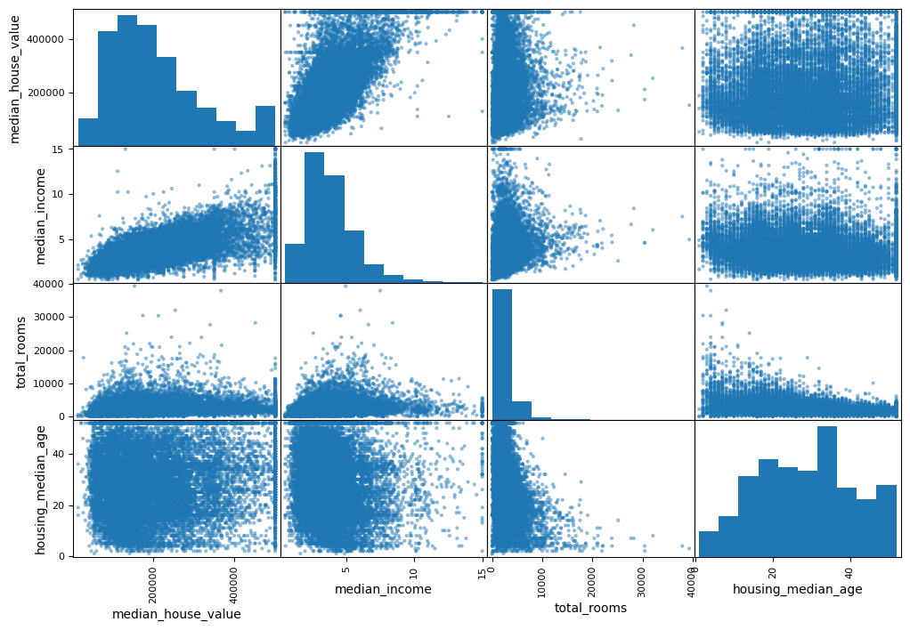

```python
from pandas.plotting import scatter_matrix
attributes = ["median_house_value", "median_income","total_rooms","housing_median_age"]
scatter_matrix(housing_train_set[attributes], figsize=(12,8))
```

Median income versus median house value

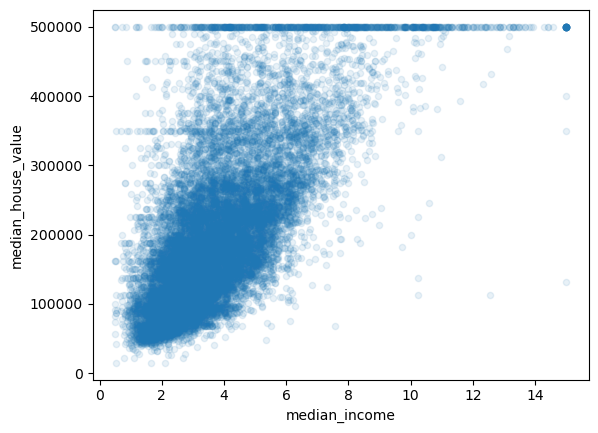

```python
housing_train_set.plot(kind="scatter", x="median_income", y="median_house_value", alpha=0.1)
```

the total number of rooms in a district is not very useful if you don’t know how many households there are.

What you really want is the number of rooms per household.

Similarly, the total number of bedrooms by itself is not very useful, What to want is the number of bedrooms per rooms.

similarly the population is not useful, what to want is the population per household.

```python
housing_train_set["rooms_per_household"] = housing_train_set["total_rooms"]/housing_train_set["households"]
housing_train_set["bedrooms_per_room"] = housing_train_set["total_bedrooms"]/housing_train_set["total_rooms"]
housing_train_set["population_per_household"] = housing_train_set["population"]/housing_train_set["households"]
```

```python
corr_matrix = housing_train_set.corr()
```

now compare median_house_value vs total_bedrooms and median_house_value vs bedrooms_per_room, then we got some relation instead of 0.04(correlation = 0)

```python
corr_matrix["median_house_value"].sort_values(ascending=False)
```

```
median_house_value          1.000000
median_income               0.687151
rooms_per_household         0.146255
total_rooms                 0.135140
housing_median_age          0.114146
households                  0.064590
total_bedrooms              0.047781
population_per_household   -0.021991
population                 -0.026882
longitude                  -0.047466
latitude                   -0.142673
bedrooms_per_room          -0.259952
Name: median_house_value, dtype: float64
```

# 9. Prepare the Data for Machine Learning Algorithms

To separate the predictors and the labels

1. drop() => creates a copy of the data and does not affect strat_train_set, housing_drop_set doesnot have median_house_value.
2. median_house_value labels assigned to housing_labels, housing_labels contains median_house_value.

```python
housing_drop_set = strat_train_set.drop("median_house_value", axis=1)
housing_labels = strat_train_set["median_house_value"].copy()
housing_labels
```

```
12655     72100.0
15502    279600.0
2908      82700.0
14053    112500.0
20496    238300.0
           ...
15174    268500.0
12661     90400.0
19263    140400.0
19140    258100.0
19773     62700.0
Name: median_house_value, Length: 16512, dtype: float64
```

```python
housing_drop_set
```

|  | longitude | latitude | housing_median_age | total_rooms | total_bedrooms | population | households | median_income | ocean_proximity | income_category |
| --- | --- | --- | --- | --- | --- | --- | --- | --- | --- | --- |
| 12655 | -121.46 | 38.52 | 29.0 | 3873.0 | 797.0 | 2237.0 | 706.0 | 2.1736 | INLAND | 2 |
| 15502 | -117.23 | 33.09 | 7.0 | 5320.0 | 855.0 | 2015.0 | 768.0 | 6.3373 | NEAR OCEAN | 5 |
| 2908 | -119.04 | 35.37 | 44.0 | 1618.0 | 310.0 | 667.0 | 300.0 | 2.8750 | INLAND | 2 |
| 14053 | -117.13 | 32.75 | 24.0 | 1877.0 | 519.0 | 898.0 | 483.0 | 2.2264 | NEAR OCEAN | 2 |
| 20496 | -118.70 | 34.28 | 27.0 | 3536.0 | 646.0 | 1837.0 | 580.0 | 4.4964 | <1H OCEAN | 3 |
| ... | ... | ... | ... | ... | ... | ... | ... | ... | ... | ... |
| 15174 | -117.07 | 33.03 | 14.0 | 6665.0 | 1231.0 | 2026.0 | 1001.0 | 5.0900 | <1H OCEAN | 4 |
| 12661 | -121.42 | 38.51 | 15.0 | 7901.0 | 1422.0 | 4769.0 | 1418.0 | 2.8139 | INLAND | 2 |
| 19263 | -122.72 | 38.44 | 48.0 | 707.0 | 166.0 | 458.0 | 172.0 | 3.1797 | <1H OCEAN | 3 |
| 19140 | -122.70 | 38.31 | 14.0 | 3155.0 | 580.0 | 1208.0 | 501.0 | 4.1964 | <1H OCEAN | 3 |
| 19773 | -122.14 | 39.97 | 27.0 | 1079.0 | 222.0 | 625.0 | 197.0 | 3.1319 | INLAND | 3 |

16512 rows × 10 columns

# 10. DATA CLEANING

In our dataset, total_bedrooms attribute has missing values, to get rid of that we have 3 options

1. Get rid of the corresponding districts.
2. Get rid of the whole attribute.
3. Set the values to some value (zero, the mean, the median, etc.)

You can accomplish these easily using DataFrame’s dropna(), drop(), and fillna() methods:

housing_drop_set.dropna(subset=["total_bedrooms"]) # option 1

housing_drop_set.drop("total_bedrooms", axis=1) # option 2

median = housing["total_bedrooms"].median() # option 3 housing_drop_set["total_bedrooms"].fillna(median, inplace=True)

It is hard to use any of the above 3 methods, once the system goes live to replace missing values in new data. for that we use Scikit learn's SimpleImputer class.

```python
from sklearn.impute import SimpleImputer
imputer = SimpleImputer(strategy='median')
```

Since the median can only be computed on numerical attributes, we need to create a copy of the data without the text attribute ocean_proximity

```python
housing_without_op = housing_drop_set.drop("ocean_proximity", axis=1)
```

Now fit the imputer instance to the training data using the fit() method

```python
imputer.fit(housing_without_op)
```

```
SimpleImputer(strategy='median')
```

The imputer has simply computed the median of each attribute and stored the result in its statistics_ instance variable.

```python
imputer.statistics_
```

```
array([-118.51   ,   34.26   ,   29.     , 2119.     ,  433.     ,
       1164.     ,  408.     ,    3.54155,    3.     ])
```

```python
housing_without_op.median().values
```

```
array([-118.51   ,   34.26   ,   29.     , 2119.     ,  433.     ,
       1164.     ,  408.     ,    3.54155])
```

```python
transformed_data = imputer.transform(housing_without_op)
```

Converting transformed_data (NumPy array) to housing_trained_cleaned (Pandas data frame)

```python
housing_trained_cleaned = pd.DataFrame(transformed_data, columns=housing_without_op.columns)
```

```python
housing_trained_cleaned
```

|  | longitude | latitude | housing_median_age | total_rooms | total_bedrooms | population | households | median_income | income_category |
| --- | --- | --- | --- | --- | --- | --- | --- | --- | --- |
| 0 | -121.46 | 38.52 | 29.0 | 3873.0 | 797.0 | 2237.0 | 706.0 | 2.1736 | 2.0 |
| 1 | -117.23 | 33.09 | 7.0 | 5320.0 | 855.0 | 2015.0 | 768.0 | 6.3373 | 5.0 |
| 2 | -119.04 | 35.37 | 44.0 | 1618.0 | 310.0 | 667.0 | 300.0 | 2.8750 | 2.0 |
| 3 | -117.13 | 32.75 | 24.0 | 1877.0 | 519.0 | 898.0 | 483.0 | 2.2264 | 2.0 |
| 4 | -118.70 | 34.28 | 27.0 | 3536.0 | 646.0 | 1837.0 | 580.0 | 4.4964 | 3.0 |
| ... | ... | ... | ... | ... | ... | ... | ... | ... | ... |
| 16507 | -117.07 | 33.03 | 14.0 | 6665.0 | 1231.0 | 2026.0 | 1001.0 | 5.0900 | 4.0 |
| 16508 | -121.42 | 38.51 | 15.0 | 7901.0 | 1422.0 | 4769.0 | 1418.0 | 2.8139 | 2.0 |
| 16509 | -122.72 | 38.44 | 48.0 | 707.0 | 166.0 | 458.0 | 172.0 | 3.1797 | 3.0 |
| 16510 | -122.70 | 38.31 | 14.0 | 3155.0 | 580.0 | 1208.0 | 501.0 | 4.1964 | 3.0 |
| 16511 | -122.14 | 39.97 | 27.0 | 1079.0 | 222.0 | 625.0 | 197.0 | 3.1319 | 3.0 |

16512 rows × 9 columns

```python
housing_trained_cleaned.info()
```

```
<class 'pandas.core.frame.DataFrame'>
RangeIndex: 16512 entries, 0 to 16511
Data columns (total 9 columns):
 #   Column              Non-Null Count  Dtype
---  ------              --------------  -----
 0   longitude           16512 non-null  float64
 1   latitude            16512 non-null  float64
 2   housing_median_age  16512 non-null  float64
 3   total_rooms         16512 non-null  float64
 4   total_bedrooms      16512 non-null  float64
 5   population          16512 non-null  float64
 6   households          16512 non-null  float64
 7   median_income       16512 non-null  float64
 8   income_category     16512 non-null  float64
dtypes: float64(9)
memory usage: 1.1 MB
```

# Scikit-Learn Design

The main design principles

Consistency: All objects share a consistent and simple interface.

```
1. Estimators: Any object that can estimate some parameters based on the dataset.
eg: imputer is an estimator
    fit() method through estimation performed.
    fit() method takes dataset as a parameter to fit into the system.
    imputer's strategy is the parameters(hyperparameters).

 2. Transformers: Estimators which transform the dataset is called Transformers.
 The transformation is performed by tranform() method, parameter as dataset.
 It returns transformed dataset.
 Also have fit_transform() => fit() + transform(), it is optimized and runs much faster.

3. Predictors: Finally these estimators are capable of making predictions by a dataset.
eg: LinearRegression is the predictor.

Predict() method takes the dataset of new instances and returns the corresponding predictions.
Also have a score() method that measures the quality of the predictions for a test set.
```

Inspection: All estimator's hyperparameters are accessible directly public instance variables.

```
eg: imputer.strategy.

All estimator's learned parameters are also accessible directly public instance variables with an underscore suffix.
eg: imputer.statistics_
```

Nonproliferation of classes: Datasets are represented as NumPy arrays or SciPy sparse matrices.

```
Hyperparameters are Python strings or numbers.
```

Composition: Create a pipeline estimator from an arbitary sequence of transformers followed by final estimator and It can be reused.

Sensible defaults: Scikit-Learn provides reasonable default values for most parameters.

# Handling Text and Categorical Attributes

Earlier we left out the categorical attribute ocean_proximity because it is a text attribute so we cannot compute its median

```python
housing_category = housing_drop_set[["ocean_proximity"]]
```

```python
housing_category
```

|  | ocean_proximity |
| --- | --- |
| 12655 | INLAND |
| 15502 | NEAR OCEAN |
| 2908 | INLAND |
| 14053 | NEAR OCEAN |
| 20496 | <1H OCEAN |
| ... | ... |
| 15174 | <1H OCEAN |
| 12661 | INLAND |
| 19263 | <1H OCEAN |
| 19140 | <1H OCEAN |
| 19773 | INLAND |

16512 rows × 1 columns

Most ML algorithms prefer to work with numerical values, so lets convert ocean_proximity values to numbers. For this we use

**Scikit-Learn’s OrdinalEncoder class**

```python
from sklearn.preprocessing import OrdinalEncoder
ordinal_encoder = OrdinalEncoder()
housing_category_encoded = ordinal_encoder.fit_transform(housing_category)
housing_category_encoded
```

```
array([[1.],
       [4.],
       [1.],
       ...,
       [0.],
       [0.],
       [1.]])
```

to get the categories of housing_category_encoded values, it returns in 1D array since the dataset contains only one categorical attribute.

```python
ordinal_encoder.categories_
```

```
[array(['<1H OCEAN', 'INLAND', 'ISLAND', 'NEAR BAY', 'NEAR OCEAN'],
       dtype=object)]
```

One issue with ordinal encoder, ML algorithms will assume that two nearby values are more similar than two distant values.

This may be fine in some cases (e.g., for ordered categories such as “bad”, “average”, “good”, “excellent”), but it is obviously not the case for the ocean_proximity column (for example, categories 0 and 4 are clearly more similar than categories 0 and 1).

To fix this issue, a common solution is to create one binary attribute per category. one attribute equal to 1 when the category is “<1H OCEAN” (and 0 otherwise), another attribute equal to 1 when the category is “INLAND” (and 0 otherwise), and so on.

This is called **one-hot Encoding**, because only one attribute will be equal to 1 (hot), while the others will be 0 (cold).

```python
from sklearn.preprocessing import OneHotEncoder
category_encoder = OneHotEncoder()
housing_category_1hot = category_encoder.fit_transform(housing_category)
housing_category_1hot
```

```
<16512x5 sparse matrix of type '<class 'numpy.float64'>'
	with 16512 stored elements in Compressed Sparse Row format>
```

output is a SciPy sparse matrix, This is very useful when you have categorical attributes with thousands of categories. After one hot encoding we get a matrix with thousands of columns, and the matrix is full of zeros except for a single 1 per row. so it is wasteful of store zeros. You can use it mostly like a normal 2D array.

```python
housing_category_1hot.toarray()
```

```
array([[0., 1., 0., 0., 0.],
       [0., 0., 0., 0., 1.],
       [0., 1., 0., 0., 0.],
       ...,
       [1., 0., 0., 0., 0.],
       [1., 0., 0., 0., 0.],
       [0., 1., 0., 0., 0.]])
```

```python
category_encoder.categories_
```

```
[array(['<1H OCEAN', 'INLAND', 'ISLAND', 'NEAR BAY', 'NEAR OCEAN'],
       dtype=object)]
```

**Representation Learning:** Instead of using onehotencoder, calculate ocean_proximity as distance between ocean and district(block groups) Replace each category with a learnable low dimensional vector called an embedding.

```python
housing_trained_cleaned
```

|  | longitude | latitude | housing_median_age | total_rooms | total_bedrooms | population | households | median_income | income_category |
| --- | --- | --- | --- | --- | --- | --- | --- | --- | --- |
| 0 | -121.46 | 38.52 | 29.0 | 3873.0 | 797.0 | 2237.0 | 706.0 | 2.1736 | 2.0 |
| 1 | -117.23 | 33.09 | 7.0 | 5320.0 | 855.0 | 2015.0 | 768.0 | 6.3373 | 5.0 |
| 2 | -119.04 | 35.37 | 44.0 | 1618.0 | 310.0 | 667.0 | 300.0 | 2.8750 | 2.0 |
| 3 | -117.13 | 32.75 | 24.0 | 1877.0 | 519.0 | 898.0 | 483.0 | 2.2264 | 2.0 |
| 4 | -118.70 | 34.28 | 27.0 | 3536.0 | 646.0 | 1837.0 | 580.0 | 4.4964 | 3.0 |
| ... | ... | ... | ... | ... | ... | ... | ... | ... | ... |
| 16507 | -117.07 | 33.03 | 14.0 | 6665.0 | 1231.0 | 2026.0 | 1001.0 | 5.0900 | 4.0 |
| 16508 | -121.42 | 38.51 | 15.0 | 7901.0 | 1422.0 | 4769.0 | 1418.0 | 2.8139 | 2.0 |
| 16509 | -122.72 | 38.44 | 48.0 | 707.0 | 166.0 | 458.0 | 172.0 | 3.1797 | 3.0 |
| 16510 | -122.70 | 38.31 | 14.0 | 3155.0 | 580.0 | 1208.0 | 501.0 | 4.1964 | 3.0 |
| 16511 | -122.14 | 39.97 | 27.0 | 1079.0 | 222.0 | 625.0 | 197.0 | 3.1319 | 3.0 |

16512 rows × 9 columns

**Custom transformers:** For custom cleanup operations or combining specific attributes.

```python
from sklearn.base import BaseEstimator, TransformerMixin
rooms_ix, bedrooms_ix, population_ix, households_ix = 3,4,5,6
class CombinedAttributesAdder(BaseEstimator, TransformerMixin):
    def __init__(self, add_bedrooms_per_room = True):
        self.add_bedrooms_per_room = add_bedrooms_per_room
    def fit(self, X, y=None):
        return self
    def transform(self, X, y=None):
        rooms_per_household = X[:, rooms_ix] / X[:, households_ix]
        population_per_household = X[:, population_ix] / X[:, households_ix]
        if self.add_bedrooms_per_room:
            bedrooms_per_room = X[:, bedrooms_ix] / X[:, rooms_ix]
            return np.c_[X, rooms_per_household, population_per_household, bedrooms_per_room]
        else:
            return np.c_[X, rooms_per_household, population_per_household]
attr_addre = CombinedAttributesAdder(add_bedrooms_per_room = False)
housing_extra_attrins = attr_addre.transform(housing_drop_set.values)
```

# Feature Scaling

Machine Learning algorithms don’t perform well when the input numerical attributes have very different scales.

The 2 common ways to get all attributes to have same scale are **min-max scaling, standardization.**

Mix-Max scaling/Normalization: values are shifted and rescaled so that they end up ranging from 0 to 1. x-min/max-min Scikit-Learn provides a transformer called MinMaxScaler. It has a feature range, can give custom range.

Standardization: x-(mean value)/standard deviation. Scikit-Learn provides a transformer called StandardScaler.

Standardization is much less affected by outliers.

Eg: suppose a district had a median income equal to 100 (by mistake). Min-max scaling would then the values from 0–15 down to 0–0.15, whereas standardization would not be much affected.

# Transaformation Pipelines

Scikit-Learn provides the Pipeline class to help with such sequences of transformations.

```python
from sklearn.pipeline import Pipeline
from sklearn.preprocessing import StandardScaler

num_pipeline = Pipeline([
    ('imputer', SimpleImputer(strategy="median")),
    ('attribs_adder', CombinedAttributesAdder()),
    ('std_scaler', StandardScaler())
])
housing_num_tr = num_pipeline.fit_transform(housing_without_op)
```

```python
housing_num_tr
```

```
array([[-0.94135046,  1.34743822,  0.02756357, ...,  0.01739526,
         0.00622264, -0.12112176],
       [ 1.17178212, -1.19243966, -1.72201763, ...,  0.56925554,
        -0.04081077, -0.81086696],
       [ 0.26758118, -0.1259716 ,  1.22045984, ..., -0.01802432,
        -0.07537122, -0.33827252],
       ...,
       [-1.5707942 ,  1.31001828,  1.53856552, ..., -0.5092404 ,
        -0.03743619,  0.32286937],
       [-1.56080303,  1.2492109 , -1.1653327 , ...,  0.32814891,
        -0.05915604, -0.45702273],
       [-1.28105026,  2.02567448, -0.13148926, ...,  0.01407228,
         0.00657083, -0.12169672]])
```

Till now, we have transformed the numerical columns, categorical columns seperately. To combine these into one transformer, Scikit-Learn introduced the **ColumnTransformer.**

```python
from sklearn.compose import ColumnTransformer
num_attribs = list(housing_without_op)
cat_attribs = ["ocean_proximity"]
full_pipeline = ColumnTransformer([
    ("num", num_pipeline, num_attribs),
    ("cat", OneHotEncoder(), cat_attribs)
])
housing_prepared = full_pipeline.fit_transform(housing_drop_set)
housing_prepared
```

```
array([[-0.94135046,  1.34743822,  0.02756357, ...,  0.        ,
         0.        ,  0.        ],
       [ 1.17178212, -1.19243966, -1.72201763, ...,  0.        ,
         0.        ,  1.        ],
       [ 0.26758118, -0.1259716 ,  1.22045984, ...,  0.        ,
         0.        ,  0.        ],
       ...,
       [-1.5707942 ,  1.31001828,  1.53856552, ...,  0.        ,
         0.        ,  0.        ],
       [-1.56080303,  1.2492109 , -1.1653327 , ...,  0.        ,
         0.        ,  0.        ],
       [-1.28105026,  2.02567448, -0.13148926, ...,  0.        ,
         0.        ,  0.        ]])
```

# Select and Train a Model

Training and Evaluating on the Training Set, Training the linear regression model.

```python
from sklearn.linear_model import LinearRegression
lin_reg = LinearRegression()
lin_reg.fit(housing_prepared, housing_labels)
some_data = housing_drop_set.iloc[:5]
some_labels = housing_labels.iloc[:5]
some_data_prepared = full_pipeline.transform(some_data)
print("Prediction: ",lin_reg.predict(some_data_prepared))
print("Labels: ",list(some_labels))
```

```
Prediction:  [ 83811.08312039 314388.27147935 145641.85902864 183704.64921202
 238729.66725745]
Labels:  [72100.0, 279600.0, 82700.0, 112500.0, 238300.0]
```

Let’s measure this regression model’s RMSE on the whole training set using Scikit-Learn’s mean_squared_error function

```python
from sklearn.metrics import mean_squared_error
housing_predictions = lin_reg.predict(housing_prepared)
lin_mse = mean_squared_error(housing_labels, housing_predictions)
lin_rmse = np.sqrt(lin_mse)
lin_rmse
```

```
68376.51254853733
```

most districts median_housing_values range between $120000 and $265000, so a typical prediction error of $68376.51254853733 is not very satisfying. This is an example of a model **underfitting** the training data. we knew that there are 3 ways to resolve underfitting problem

1. To select a more powerful model.
2. To feed the training algorithm with better features.
3. To reduce the constraints on the model.

```python
# 1. To select a more powerful model
# Let’s train a DecisionTreeRegressor
from sklearn.tree import DecisionTreeRegressor
tree_reg = DecisionTreeRegressor()
tree_reg.fit(housing_prepared, housing_labels)
```

```
DecisionTreeRegressor()
```

```python
some_data = housing_drop_set.iloc[:5]
some_labels = housing_labels.iloc[:5]
some_data_prepared = full_pipeline.transform(some_data)
print("Prediction: ",tree_reg.predict(some_data_prepared))
print("Labels: ",list(some_labels))
```

```
Prediction:  [ 72100. 279600.  82700. 112500. 238300.]
Labels:  [72100.0, 279600.0, 82700.0, 112500.0, 238300.0]
```

```python
housing_predictions = tree_reg.predict(housing_prepared)
tree_mse = mean_squared_error(housing_labels, housing_predictions)
tree_rmse = np.sqrt(tree_mse)
tree_rmse
```

```
0.0
```

It is much more likely that the model has badly overfit the data.

**Better Evaluation Using Cross-Validation**

One way to evaluate the Decision Tree model would be to use the train_test_split function to split the training set into a smaller training set and a validation set, then train your models against the smaller training set and evaluate them against the validation set.

Alternatively, use Scikit-Learn’s K-fold cross-validation feature. The following code randomly splits the training set into 10 distinct subsets called folds, then it trains and evaluates the Decision Tree model 10 times, picking a different fold for evaluation every time and training on the other 9 folds. The result is an array containing the 10 evaluation scores.

```python
from sklearn.model_selection import cross_val_score
scores = cross_val_score(tree_reg, housing_prepared, housing_labels,
                        scoring = "neg_mean_squared_error", cv=10)
tree_rmse_scores = np.sqrt(-scores)
```

Scikit-Learn’s cross-validation features expect a utility function (greater is better) rather than a cost function (lower is better), so the scoring function is actually the **opposite of the MSE** (i.e., a negative value), which is why the preceding code computes -scores before calculating the square root.

```python
def display_scores(scores):
    print("Scores: ", scores)
    print("Mean: ", scores.mean())
    print("Standard deviation: ", scores.std())
display_scores(tree_rmse_scores)
```

```
Scores:  [72185.96628577 70750.35916739 68810.16542331 71716.59649118
 68937.91206821 78138.73034122 71506.63717072 73025.93795506
 67014.85389491 71112.52344582]
Mean:  71319.96822435834
Standard deviation:  2849.960706449774
```

For this we used cross validation and we got to know this model also not correct but if there is large amount of instances in a dataset then Cross validation is not the best way to use, because it takes lot of time.

**Let’s cross validate Linear Regression model just to be sure:**

```python
lin_scores = cross_val_score(lin_reg, housing_prepared, housing_labels,
                        scoring = "neg_mean_squared_error", cv=10)
lin_rmse_scores = np.sqrt(-lin_scores)
display_scores(lin_rmse_scores)
```

```
Scores:  [71523.78333874 64044.46774989 67454.97869698 68514.10137273
 66303.62531226 72166.63405138 74464.08841381 68570.11804395
 66063.64175868 69870.86192291]
Mean:  68897.63006613276
Standard deviation:  3002.746127534863
```

That’s right: the Decision Tree model is overfitting so badly that it performs worse than the Linear Regression model.

Let’s try one last model now: the **RandomForestRegressor.**

Random Forests work by training many Decision Trees on random subsets of the features, then averaging out their predictions. Building a model on top of many other models is called **Ensemble Learning.**

```python
from sklearn.ensemble import RandomForestRegressor
forest_reg = RandomForestRegressor()
forest_reg.fit(housing_prepared, housing_labels)
```

```
RandomForestRegressor()
```

```python
housing_predictions = forest_reg.predict(housing_prepared)
forest_mse = mean_squared_error(housing_labels, housing_predictions)
forest_rmse = np.sqrt(forest_mse)
forest_rmse
```

```
18733.353475801105
```

```python
forest_scores = cross_val_score(forest_reg, housing_prepared, housing_labels,
                        scoring = "neg_mean_squared_error", cv=10)
forest_rmse_scores = np.sqrt(-forest_scores)
display_scores(forest_rmse_scores)
```

```
Scores:  [51132.86307783 49212.64313499 46793.41217315 51822.32597489
 47439.60444845 52126.5540138  52445.71675845 50022.76136483
 49069.35858176 53988.74256535]
Mean:  50405.39820934913
Standard deviation:  2184.0095364451963
```

Wow, this is much better than the other above 2 models. Random Forests look very promising. However, the score on the training set is still much lower than on the validation sets, meaning that the model is still overfitting the training set. Possible solutions for overfitting as we knew are to simplify the model, constrain it (i.e., regularize it), or get a lot more training data.

However, before going forward with overfitting in Random Forests i.e hyperparameter tuning, try out many other models from various categories of Machine Learning algorithms (several Support Vector Machines with different kernels, possibly a neural network, etc.). SHortlist 2 to 5 models.

You should save every model you experiment with, so you can come back easily to any model you want. Make sure you save both the hyperparameters and the trained parameters, as well as the cross-validation scores and perhaps the actual predictions as well. This will allow you to easily compare scores across model types, and compare the types of errors they make. You can easily save **Scikit-Learn models by using Python’s pickle module, or using sklearn.externals.joblib**, which is more efficient at serializing large NumPy arrays.

# Fine-Tune Model

The next step after selecting the models is to Fine-Tune the models.

1. **Grid Search :** To search the hyperparameters combination values manually it is time taking and hard. Instead we have Scikit-Learn's GridSearchCV to search. All we need to do is tell which hyperparameters want to experiment with and what values to try out and it will evaluate all the possible combinations of hyperparameter values using cross-validation.

```python
from sklearn.model_selection import GridSearchCV
param_grid = [
    {'n_estimators': [3,10,30,40,50,60,70], 'max_features': [2,4,6,8,10,12]},
    {'bootstrap': [False], 'n_estimators': [3,10], 'max_features': [2,3,4]},
]
forest_reg = RandomForestRegressor()
grid_search = GridSearchCV(forest_reg, param_grid, cv=5,
                          scoring='neg_mean_squared_error',
                          return_train_score=True)
grid_search.fit(housing_prepared, housing_labels)
```

```
GridSearchCV(cv=5, estimator=RandomForestRegressor(),
             param_grid=[{'max_features': [2, 4, 6, 8, 10, 12],
                          'n_estimators': [3, 10, 30, 40, 50, 60, 70]},
                         {'bootstrap': [False], 'max_features': [2, 3, 4],
                          'n_estimators': [3, 10]}],
             return_train_score=True, scoring='neg_mean_squared_error')
```

```python
grid_search.best_params_
```

```
{'max_features': 8, 'n_estimators': 70}
```

```python
# Also can get the best estimator directly,
grid_search.best_estimator_
```

```
RandomForestRegressor(max_features=8, n_estimators=70)
```

```python
cvres = grid_search.cv_results_
for mean_score, params in zip(cvres["mean_test_score"], cvres["params"]):
    print(np.sqrt(-mean_score), params)
```

```
63749.04174773073 {'max_features': 2, 'n_estimators': 3}
55570.07885523297 {'max_features': 2, 'n_estimators': 10}
53128.446290593405 {'max_features': 2, 'n_estimators': 30}
52606.24257876055 {'max_features': 2, 'n_estimators': 40}
52320.950094826854 {'max_features': 2, 'n_estimators': 50}
52432.16229430384 {'max_features': 2, 'n_estimators': 60}
52427.485561344714 {'max_features': 2, 'n_estimators': 70}
61198.61524899578 {'max_features': 4, 'n_estimators': 3}
53301.75032324741 {'max_features': 4, 'n_estimators': 10}
51649.16001172997 {'max_features': 4, 'n_estimators': 30}
51120.628545856845 {'max_features': 4, 'n_estimators': 40}
50809.32137763383 {'max_features': 4, 'n_estimators': 50}
50812.84850704417 {'max_features': 4, 'n_estimators': 60}
50643.33534317582 {'max_features': 4, 'n_estimators': 70}
59908.31106025328 {'max_features': 6, 'n_estimators': 3}
53140.907786015545 {'max_features': 6, 'n_estimators': 10}
51019.410848646665 {'max_features': 6, 'n_estimators': 30}
50672.89152606121 {'max_features': 6, 'n_estimators': 40}
50433.04583480559 {'max_features': 6, 'n_estimators': 50}
50315.23710277961 {'max_features': 6, 'n_estimators': 60}
50429.75270439826 {'max_features': 6, 'n_estimators': 70}
59501.174841053864 {'max_features': 8, 'n_estimators': 3}
53114.612264644886 {'max_features': 8, 'n_estimators': 10}
50873.22213440149 {'max_features': 8, 'n_estimators': 30}
50356.72814777384 {'max_features': 8, 'n_estimators': 40}
50452.1446541042 {'max_features': 8, 'n_estimators': 50}
50447.67029546025 {'max_features': 8, 'n_estimators': 60}
50282.743120413674 {'max_features': 8, 'n_estimators': 70}
59049.52656236818 {'max_features': 10, 'n_estimators': 3}
52572.40928462517 {'max_features': 10, 'n_estimators': 10}
50706.3832755168 {'max_features': 10, 'n_estimators': 30}
50452.31249062047 {'max_features': 10, 'n_estimators': 40}
50553.196659653775 {'max_features': 10, 'n_estimators': 50}
50331.57198653746 {'max_features': 10, 'n_estimators': 60}
50393.77612843911 {'max_features': 10, 'n_estimators': 70}
59069.842349149556 {'max_features': 12, 'n_estimators': 3}
52798.882311639434 {'max_features': 12, 'n_estimators': 10}
50875.550911204016 {'max_features': 12, 'n_estimators': 30}
50662.41952735663 {'max_features': 12, 'n_estimators': 40}
50586.0012368265 {'max_features': 12, 'n_estimators': 50}
50367.90140712904 {'max_features': 12, 'n_estimators': 60}
50398.43189041339 {'max_features': 12, 'n_estimators': 70}
62184.9892669045 {'bootstrap': False, 'max_features': 2, 'n_estimators': 3}
54870.52311024703 {'bootstrap': False, 'max_features': 2, 'n_estimators': 10}
60659.557690979294 {'bootstrap': False, 'max_features': 3, 'n_estimators': 3}
53039.73390310134 {'bootstrap': False, 'max_features': 3, 'n_estimators': 10}
59079.71194978017 {'bootstrap': False, 'max_features': 4, 'n_estimators': 3}
52540.77898137208 {'bootstrap': False, 'max_features': 4, 'n_estimators': 10}
```

Now for 50282.743120413674 {'max_features': 8, 'n_estimators': 70}, is the mean value while using RandomForestRegressor model. that means it is better than 50405.39820934913, so we fine-tuned the model.

we can give more numbers for n_estimators to fine-tune the model again but it consumes more time and money so that is why we have better way which is **RandomizedSearch**

**RandomizedSearch:** It evaluates a given number of random combinations by selecting a random value for each hyperparameter at every iteration.

**Ensemble Methods** The other way to fine-tune is to combine the models that perform best.

## Analyze the Best Models and Their Errors

The RandomForestRegressor can indicate the relative importance of each attribute for making accurate predictions:

```python
feature_importances = grid_search.best_estimator_.feature_importances_
feature_importances
```

```
array([6.17043073e-02, 5.63491192e-02, 4.65438239e-02, 1.62077852e-02,
       1.56105265e-02, 1.61828707e-02, 1.55920205e-02, 2.94641108e-01,
       1.50387668e-01, 3.36406768e-02, 1.09022004e-01, 4.25346651e-02,
       5.78433088e-03, 1.30083150e-01, 7.22467814e-05, 2.16107394e-03,
       3.48262363e-03])
```

Let’s display these importance scores next to their corresponding attribute names

```python
extra_attribs = ["rooms_per_hhold", "pop_per_hhold", "bedrooms_per_room"]
cat_encoder = full_pipeline.named_transformers_["cat"]
cat_one_hot_attribs = list(cat_encoder.categories_[0])
attributes = num_attribs + extra_attribs + cat_one_hot_attribs
sorted(zip(feature_importances, attributes), reverse = True)
```

```
[(0.2946411077705138, 'median_income'),
 (0.15038766764537673, 'income_category'),
 (0.1300831498404753, 'INLAND'),
 (0.10902200436864538, 'pop_per_hhold'),
 (0.06170430729735026, 'longitude'),
 (0.056349119183253256, 'latitude'),
 (0.04654382388572061, 'housing_median_age'),
 (0.04253466507061956, 'bedrooms_per_room'),
 (0.03364067679129908, 'rooms_per_hhold'),
 (0.016207785187254985, 'total_rooms'),
 (0.016182870698904485, 'population'),
 (0.01561052647831724, 'total_bedrooms'),
 (0.015592020548887307, 'households'),
 (0.005784330883617637, '<1H OCEAN'),
 (0.003482623629569464, 'NEAR OCEAN'),
 (0.0021610739388152056, 'NEAR BAY'),
 (7.224678137974793e-05, 'ISLAND')]
```

Here we can drop some of the less useful features, eg: one ocean_proximity category is usefull, so could try dropping others.

# Evaluate Your System on the Test Set

Now is the time to evaluate the final model on the test set with the predictors and the labels from the test set, run the full_pipeline to transform the data (call transform(), not fit_transform(), Do not want to fit the test set!).

```python
final_model = grid_search.best_estimator_
X_test = strat_test_set.drop("median_house_value", axis = 1)
y_test = strat_test_set["median_house_value"].copy()
X_test_prepared = full_pipeline.transform(X_test)
final_predictions = final_model.predict(X_test_prepared)
final_mse = mean_squared_error(y_test, final_predictions)
final_rmse = np.sqrt(final_mse)
final_rmse
```

```
48327.94303748702
```

In some cases 48327 generalization error will not be enough to convince to launch in production. What if it is just 0.1% better than the model currently in production? For that we need to have an idea of how precise the estimate is. For this, **compute a 95% confidence interval for the generalization error using scipy.stats.t.interval()**

```python
from scipy import stats
confidence = 0.95
squared_errors = (final_predictions - y_test) ** 2
np.sqrt(stats.t.interval(confidence, len(squared_errors) - 1,
                        loc=squared_errors.mean(),
                        scale = stats.sem(squared_errors)))
```

```
array([46295.45343932, 50278.33675965])
```

## Launch, Monitor, and Maintain Your System

Perfect, Got approval to launch! Now need to get the solution ready for production, in particular by plugging the production input data sources into the system and writing tests. Now also need to write monitoring code to check the system’s live performance at regular intervals and trigger alerts when it drops. This is important to catch not only sudden breakage, but also performance degradation. This is quite common unless the models are regularly trained on fresh data(online training).

Monitoring the inputs is particularly important for online learning systems. Finally, Will generally want to train your models on a regular basis using fresh data to automate this process as much as possible. If not, there are very likely to refresh the model only every six months (at best), and the system’s performance may fluctuate severely over time. If the system is an online learning system, should make sure to save snapshots of its state at regular intervals so that can easily roll back to a previously working state.